# Temperature Data Evaluation in Kaiser Sepsis Cohort

2025-08-14

# Load in cohort membership SAS data

```r
patients <- haven::read_sas(paste0("/Shared/AML/kaiser_data/sepsis/sepsis_cohort_12sep23final.sas7bdat"))
```

# Load in raw SAS vitals data

```r
vital_signs_info <- haven::read_sas(paste0("/Shared/AML/kaiser_data/sepsis/sepsis_vital_signs_12sep23final.sas7bdat"))
```

# Load in raw SAS encounters data

```r
all_dx <- haven::read_sas(paste0("/Shared/AML/kaiser_data/sepsis/sepsis_enc_diag_12sep23final.sas7bdat"))
```

# Number of patients in cohort with at least 180 days of enrollment prior to index

```r
enrolled_180 <- patients %>%
  filter(enroll_before >= 180) %>%
  distinct(STUDYID)

enrolled_180 %>% nrow
```

```
## [1] 21480
```

# Number of patients enrolled for >=180 days with at least one vital reading

```r
vital_signs_info <- vital_signs_info %>%
  inner_join(enrolled_180, by = "STUDYID")

vital_signs_info%>%
  distinct(STUDYID) %>%
  nrow()
```

```
## [1] 21079
```

So of the 21,480 patients enrolled for >=180 days prior to index, 401 had no vital data at all

# Check to see if each obs in vitals table has at least one non missing measurement for DIASTOLIC, SYSTOLIC, PULSE, RESP, or TEMP

```r
vital_signs_info %>%
  filter(is.na(diastolic) & is.na(systolic) & is.na(pulse) & is.na(resp) & is.na(temp))
```

```
## # A tibble: 0 x 10
## # i 10 variables: STUDYID <chr>, measurement_date <date>,
## #   measurement_time <time>, diastolic <dbl>, systolic <dbl>,
## #   encounter_type <chr>, enc_id <chr>, pulse <dbl>, resp <dbl>, temp <dbl>
```

# Check to see if there are obs in vitals table where diastolic is recorded but systolic is not or vice versa

```r
vital_signs_info %>%
  filter(xor(is.na(diastolic), is.na(systolic)))
```

```
## # A tibble: 1,875 x 10
##    STUDYID  measurement_date measurement_time diastolic systolic encounter_type
##    <chr>    <date>           <time>               <dbl>    <dbl> <chr>
##  1 SE000019 2017-06-22          NA                   NA      186 IP
##  2 SE000060 2021-07-26       02:44                   NA      185 IP
##  3 SE000144 2020-05-30       12:00                   26       NA IP
##  4 SE000144 2020-05-30       13:15                   NA       84 IP
##  5 SE000144 2020-05-30       13:45                   NA       85 IP
##  6 SE000144 2020-05-30       15:25                   39       NA IP
##  7 SE000144 2020-05-30       15:40                   28       NA IP
##  8 SE000158 2022-03-30       07:25                   NA      184 IP
##  9 SE000158 2022-03-30       07:35                   NA      244 IP
## 10 SE000158 2022-03-30       08:01                   NA       67 IP
## # i 1,865 more rows
## # i 4 more variables: enc_id <chr>, pulse <dbl>, resp <dbl>, temp <dbl>
```

1,875 observations where diastolic is recorded but systolic is not or vice versa

# Check ranges for each of the vitals

```r
vital_signs_info %>%
  select(diastolic, systolic, pulse, resp, temp) %>%
  pivot_longer(cols = everything(), names_to = "vitals", values_to = "value") %>%
  group_by(vitals) %>%
  summarise(Range = paste0(range(value, na.rm = T), collapse = " - "))
```

```
## # A tibble: 5 x 2
##   vitals    Range
##   <chr>     <chr>
## 1 diastolic 20 - 160
## 2 pulse     0 - 264
## 3 resp      0 - 189
## 4 systolic  50 - 285
## 5 temp      33.8 - 137
```

We can see some abnormalities with the values recorded for the vitals. For example someone had a temp of 33.8F recorded and another 137F.

# Check to see how many obs has missing temp

```r
vital_signs_info %>%
  count(is.na(temp)) %>%
  mutate(percent = n/sum(n)*100)
```

```
## # A tibble: 2 x 3
##   `is.na(temp)`       n percent
##   <lgl>           <int>   <dbl>
## 1 FALSE          380232    14.1
## 2 TRUE          2307527    85.9
```

85.9% of the vital records are missing temperature readings.

```r
vital_signs_info %>%
  filter(is.na(temp)) %>%
  count(encounter_type) %>%
  mutate(percent = n/sum(n)*100)
```

```
## # A tibble: 10 x 3
##    encounter_type       n   percent
##    <chr>            <int>     <dbl>
##  1 ""                   6  0.000260
##  2 "AV"            411562 17.8
##  3 "DE"              8617  0.373
##  4 "ED"             73068  3.17
##  5 "IP"           1755944 76.1
##  6 "IS"              4888  0.212
##  7 "LO"              2726  0.118
##  8 "OE"             38013  1.65
##  9 "RO"               213  0.00923
## 10 "VC"             12490  0.541
```

The majority of missing temps occured in IP = Acute inpatient hospital stay and AV = Ambulatory visit.

# Patients could have multiple temp readings on a given day, so collapse to visit day by looking at max temp on a given day and see how many are missing

```r
vital_signs_info_visit_day <- vital_signs_info %>%
  group_by(STUDYID, measurement_date) %>%
  summarise(temp = max(temp)) %>%
  ungroup()

vital_signs_info_visit_day %>%
  count(is.na(temp)) %>%
  mutate(percent = n/sum(n)*100)
```

```
## # A tibble: 2 x 3
##   `is.na(temp)`      n percent
##   <lgl>          <int>   <dbl>
## 1 FALSE         231958    34.0
## 2 TRUE          449635    66.0
```

66.0% of the recored vitals on a given visit-day are missing temperature readings.

# Distribution of non-missing temp

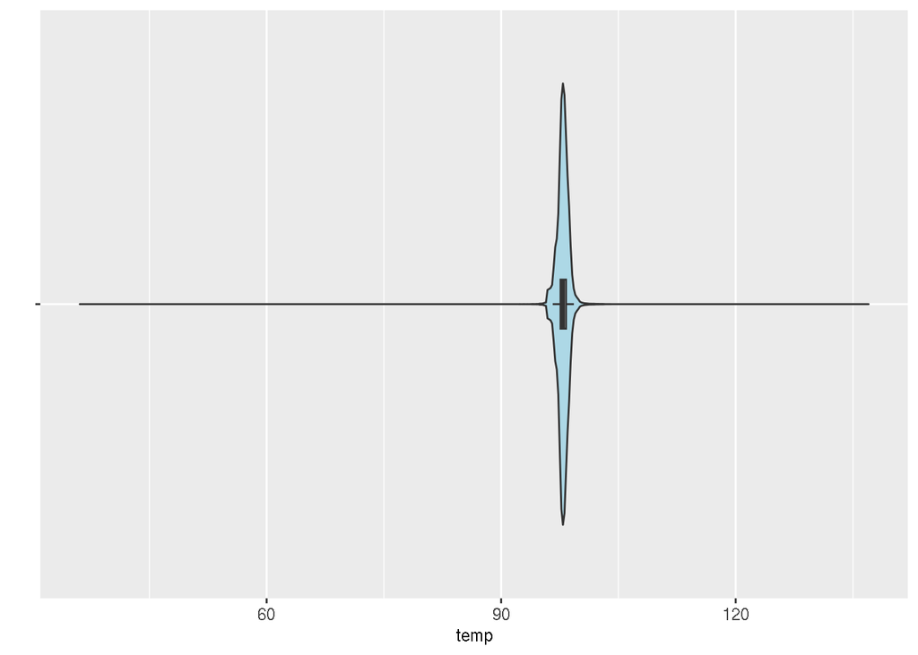

```r
vital_signs_info_visit_day %>%
  filter(!is.na(temp)) %>%
  ggplot(aes(x = "", y = temp)) +
  geom_violin(fill = "lightblue") +
  geom_boxplot(width = 0.1, fill = "white", outlier.shape = NA) +
  coord_flip()+
  xlab("")
```

# Count of unreasonable temp readings

```r
vital_signs_info_visit_day %>%
  count(between(temp, 95,105)) %>%
  mutate(percent = n/sum(n)*100)
```

```
## # A tibble: 3 x 3
##   `between(temp, 95, 105)`      n percent
##   <lgl>                     <int>   <dbl>
## 1 FALSE                       248  0.0364
## 2 TRUE                     231710 34.0
## 3 NA                       449635 66.0
```

248 visit-days had temperature readings that are outside the range of a reasonable temperature reading.

# Check if temp readings are reliable based on recorded fever diagnosis in encounters table

```r
# fever dx codes
fever_codes <- tibble(dx = codeBuildr::load_symptom_codes("fever")$icd9_codes,
       dx_ver = "09") %>%
  bind_rows(tibble(dx = codeBuildr::load_symptom_codes("fever")$icd10_codes,
                   dx_ver = "10"))

all_dx <- all_dx %>%
  inner_join(enrolled_180) %>%
  mutate(dx = str_remove_all(dx, "\\.")) %>%
  rename(dx_ver = dx_codetype)

all_dx_w_fever <- all_dx %>%
  left_join(fever_codes %>% mutate(fever_dx = 1L), by = c("dx", "dx_ver"))  %>%
  mutate(fever_dx = replace_na(fever_dx, 0L)) %>%
  group_by(STUDYID, encounter_date) %>%
  summarise(fever_dx = max(fever_dx)) %>%
  ungroup() %>%
  mutate(fever_dx = factor(fever_dx, levels = c(1,0)))

all_dx_w_fever_temp <- all_dx_w_fever %>%
  left_join(vital_signs_info_visit_day %>% rename(encounter_date = measurement_date),
            by = c("STUDYID", "encounter_date"))

compute_metrics <- function(cutoff){
  temp <- all_dx_w_fever_temp %>%
    mutate(ind = factor(temp >= cutoff, labels = c(1,0), levels = c(T,F)))
  tab <- table( "Temp >= cutoff" = temp$ind, "Fever Dx" = temp$fever_dx)

  cat("Contingency table:\n")
  print(tab)

   cat("Sensitivity:", prop.table(tab, margin = 2)[1,1], "\n")
   cat("Specificity:", prop.table(tab, margin = 2)[2,2], "\n")
   cat("PPV:", prop.table(tab, margin = 1)[1,1], "\n")
   cat("NPV:", prop.table(tab, margin = 1)[2,2], "\n")
   cat("Kappa:", psych::cohen.kappa(tab)$kappa,"\n")
}
```

### Temp cuttoff >= 100

```r
compute_metrics(100)
```

```
## Contingency table:
##               Fever Dx
## Temp >= cutoff      1      0
##              1    491    822
##              0   1288 181874
## Sensitivity: 0.2759978
## Specificity: 0.9955007
## PPV: 0.3739528
## NPV: 0.992968
## Kappa: 0.3119586
```

### Temp cuttoff >= 100.4

```r
compute_metrics(100.4)
```

```
## Contingency table:
##               Fever Dx
## Temp >= cutoff      1      0
##              1    379    439
##              0   1400 182257
## Sensitivity: 0.213041
## Specificity: 0.9975971
## PPV: 0.4633252
## NPV: 0.9923771
## Kappa: 0.2875471
```

### Temp cuttoff >= 101.3

```r
compute_metrics(101.3)
```

```
## Contingency table:
##               Fever Dx
## Temp >= cutoff      1      0
##              1    215    150
##              0   1564 182546
## Sensitivity: 0.1208544
## Specificity: 0.999179
## PPV: 0.5890411
## NPV: 0.9915051
## Kappa: 0.1979261
```

### Temp cuttoff >= 103

```r
compute_metrics(103)
```

```
## Contingency table:
##               Fever Dx
## Temp >= cutoff      1      0
##              1     37     28
##              0   1742 182668
## Sensitivity: 0.0207982
## Specificity: 0.9998467
## PPV: 0.5692308
## NPV: 0.9905537
## Kappa: 0.03947713
```

In general, as we increase the cuttoff from 100 to 101.3, the number of false positives decreases (PPV goes up and specificity goes up) while the number of false negatives increases (sensitivity goes down). The stricter cutoff means fewer observations are classified as fever, but among those classified as fever, they are more likely to also have a fever dx.

The low Kappa values suggest that the recorded temperature measurements may not reliably reflect the fever diagnosis.

# Missing temp readings by fever dx

```r
all_dx_w_fever_temp %>% count(fever_dx, missing_temp = is.na(temp)) %>%
  group_by(fever_dx) %>%
  mutate(percent = n/sum(n)*100)
```

```
## # A tibble: 4 x 4
## # Groups:   fever_dx [2]
##   fever_dx missing_temp       n percent
##   <fct>    <lgl>          <int>   <dbl>
## 1 1        FALSE           1779    12.7
## 2 1        TRUE           12236    87.3
## 3 0        FALSE         182696    12.6
## 4 0        TRUE         1272371    87.4
```

The proportion of visit days missing a temp is similar by whether or not the visit day involved a fever diagnosis.

### Density plots of temperature readings by fever diagnosis

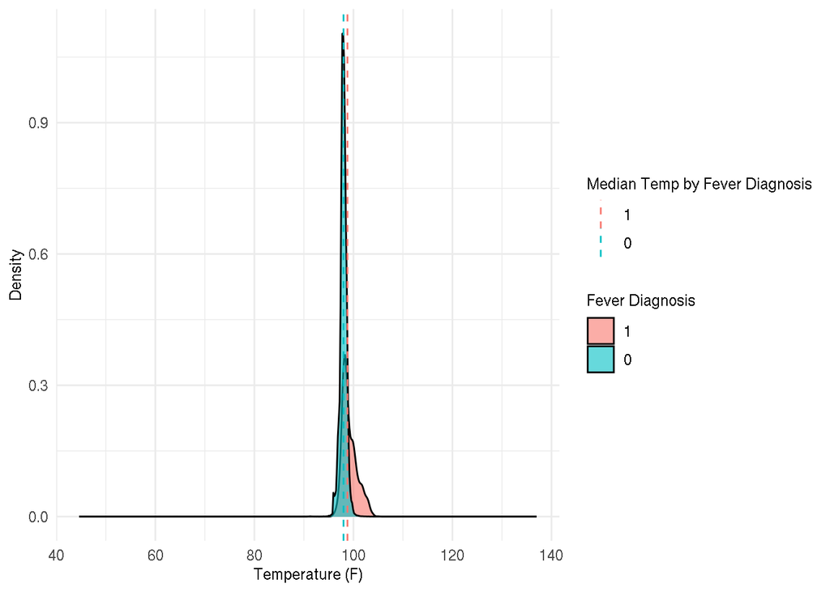

```r
# Compute medians per group
medians <- all_dx_w_fever_temp %>%
  group_by(fever_dx) %>%
  summarise(med_temp = median(temp, na.rm = T))


all_dx_w_fever_temp %>%
  ggplot(aes(x = temp, fill = fever_dx)) +
  geom_density(alpha = 0.6, position = "identity") +
  geom_vline(data = medians, aes(xintercept = med_temp, color = fever_dx), linetype = "dashed") +
  labs(x = "Temperature (F)", y = "Density", fill = "Fever Diagnosis", color = "Median Temp by Fever Diagnosis") +
  theme_minimal()
```

The distribution of temperature reading seems to be shifted more to the right for observations with a fever diagnosis, which makes sense. However, there is substantial overlap present in temperature readings between visits involving and not involving a fever diagnosis.